### Workshop: “Getting to know R!”

#### Overview

##### Introduction and set-up

1. Creating a new project
2. Opening a new R script
3. Setting the working directory
4. Understanding the R Studio infrastructure
5. R versions

##### Diving deeper into R script

6. First tries: R as a calculator
7. Taking notes in the script
8. Saving code

##### Objects

9. Creating objects
10. Deleting objects from the global environment
11. Updating objects
12. Object types and structures

##### Importing data

13. Saving data in the working directory
14. Importing CSV data

##### Inspecting data

15. Ocular inspection of the data frame
16. Inspecting a data frame using functions

##### Functions

17. Using built-in functions
18. Creating your own functions

##### Packages

19. Installing and loading packages
20. Using functions from packages

##### Advanced coding: If statements and for loops

21. If and if-else statements
22. For loops
23. Subsetting
24. Syntax and Piping

### Introduction and set-up

What is R? And how is it different from R Studio?

R is a programming **language** and software environment for statistical computing and graphics. It is widely used among statisticians and data scientists for data analysis and visualization. R has a large and active user community, which has developed a wide range of packages (you will learn what that is later) for specific tasks and a large set of data sets, that can be used by researchers.

R Studio, on the other hand, is an integrated development **environment** for R. It provides a user-friendly interface for working with R, and includes tools for editing and debugging code, managing packages and environments, and visualizing data and results.

Before you can get started coding, you need to take a few steps to set up your R session. This includes creating a new project (or opening an already existing one), setting the working directory and understanding the infrastructure of R Studio.

##### 1. Creating a new project

First of all, open R Studio.

To create a new project go to the menu bar and click on:

File > New Project > New Directory > New Project > Directory Name: *here you enter a name for your project, e.g. “Coursework”* > Browse: *click on browse to choose a location and save the new project on your computer, this will create a new folder where you will save all your data, code, etc. related to this project, note: choose a location that is on your computer, for example, the desktop. Do not save your project in a cloud or dropbox.* > Create Project

##### 2. Opening a new R script

To open a new R script go to the menu bar and click on: File > New File > R Script

Next, you want to save this R script in the project folder that you created in step 1. Therefore you click on the blue diskette icon

[figure not shown]

and select the folder you just created, in our example the folder named “Coursework”. Name your script, e.g. “lab_1”. Instead of clicking on the diskette icon you can also use the keyboard short cut cmd + s (Mac) or ctrl + s (Windows).

##### 3. Setting the working directory

In order for R to know where to find the script and (later) data you need to determine a sort of home folder for the current working session. Therefore you set your ‘working directory’ to the newly created project folder. You should repeat this step every time you open your project in R, to make sure that you do not run into error messages.

To set the working directory go to the menu bar and click on:

Session > Set Working Directory > To Source File Location

Alternatively you can use setwd() and include the file path to your working directory in the parentheses.

##### 4. Understanding the R Studio infrastructure

After having opened a new R script, the window of R Studio will be split into four areas (panes):

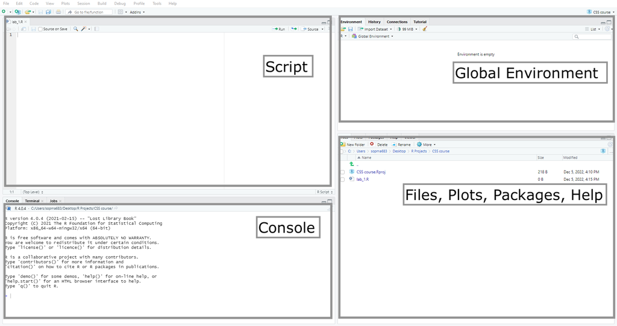

In the upper left corner you find the **script**, underneath which is the **console**. On the right hand side you have the **global environment** and a window with **files, plots, packages, help, etc**. Here is a more detailed description of each pane:

| Pane | Function |
| --- | --- |
| Console | Here you can type code which will immediately be executed. It is also the pane in which the output of your code and error messages are displayed. For example, you can try typing 2+2 into the console a… |
| Script or Source Editor | R script looks essentially like a text file. While code in the console will not be saved and disappear into the history of your output, code that you type into your script will be saved. It is like a … |
| Global Environment | This pane shows which objects have been defined in R. These can be data sets, variables, values, etc. The global environment can be cleaned by clicking on the brush icon. This can be useful if you wan… |
| Files, Plots, Packages, Help | This pane shows you your current work directory. Since we defined our work directory to be the project folder, we can see all the files that are currently in your project folder. Later on, R Studio wi… |

##### 5. R versions

The R development core team and affiliated foundation release new versions of the programming language R on a regular basis. You can see the version of R that you are currently using in the console when first opening R Studio. It is recommended to update to a newer version for the most recent bug fixes now and then. R versions are numbered and always come with a new creative name. You can download the newest version from the official [R project website](https://www.r-project.org).

### Diving deeper into R script

You already opened an R script and learned about its basic ideas (see step 2 and 4 above). Now it is time to explore a bit further:

##### 6. First tries: R as a calculator

To get started you can play around R by using it as a calculator. You can, for example, type a calculation into the console (lower left pane), hit enter and R will print out the result for you.

```r
3+9
```

```
## [1] 12
```

```r
99/3
```

```
## [1] 33
```

If you now want to save that code or complicate it a bit by assigning values to variables, you can type your code into the script (upper left pane). Once you typed your code into the script, you can execute it either by highlighting the lines that you want to run and clicking “run” (upper right corner of the script pane) or by using a key combination cmd + enter (Mac) or ctrl + enter (Windows). The output will be displayed in the console. Note that while you see the output in the console, your code in the script remains tidy and untouched. You can run that same line of code over and over again. Therefore, highlight the line of code in the script and press “run” again. You will now see the same calculation printed out in the console a second time.

```r
a = 3
b = 9
c = 99

a + b
```

```
## [1] 12
```

```r
c / a
```

```
## [1] 33
```

Note that if you make changes to your code in the script, for example by changing the values assigned to the variables, you can do so and execute the same code again. This is one of the great advantages of saving your code as script.

##### 7. Taking notes in the script

It is recommended to structure your code. For that you can use headlines and add comments for you to later remember details about a certain line of code. Comments and headlines can be added by placing a number sign (#) in front of a line of text. Words that follow a number sign will not be interpreted as code by R and hence do not influence the execution of code.

```r
# Structuring code and adding comments in the R script
# Note that R uses a different color for comments than for other parts of the code

# Example:
a = 5
b = 10
a + b # comment
```

```
## [1] 15
```

##### 8. Saving code

While storing all your important code neatly in a script it is recommended to save the newest version of the script now and then (similar to any other documents that you are working on). This can be done manually by clicking on the little discette symbol

[figure not shown]

(upper left corner of the script pane) or by using the usual key combination for saving documents cmd + s (Mac) and ctrl+ s (Windows).

The script is saved in the project folder that you set as a working directory. It has the name you assigned to it in the beginning and has the ending .R . You can see it listed in the project folder in the bottom right pane or when opening the project folder the conventional way in your file explorer.

The next time you would like to work on the code for this project, you can simply open up the script again and execute the code. Note that you never save any output but only the commands. As such, you run the same code anew each time. This ensures replicability and allows for the recycling of code. In fact, few coders write their code completely from scratch. It is common to reuse lines of code or to search the internet for suitable code that is then copied into the script and adjusted.

### Objects

What are known as objects in R are known as variables in many other programming languages. Depending on the context, object and variable can have drastically different meanings. However, in this lesson, we will stick to objects since we use the term variables in its statistical sense later (when working with data frames). R “remembers” data by creating objects. These objects can store many different types of data, ranging from mathematical calculations, tables, lists or text. Objects are thus a fundamental part of the code and can be generated, modified, emptied and deleted by the coder.

##### 9. Creating objects

To create an object, you usually need to give it a name and designate a value to it. You assign a value to an object by using the operator: <- . Here is an example of how an object is assigned:

```r
# Example 1
# We assign the value 10 to a object that we create (object_a)
object_a <- 10

# You can see that your new object is now listed in the global environment

# Now we can print our object to see what it contains
print(object_a)
```

```
## [1] 10
```

```r
# Example 2
# In the section above we have learned that there are different object types.
# Example 1 demonstrated how we assign a numerical value to an object However, we can also assign character strings to our variable:

# Example 2
object_b <- "January"
print(object_b)
```

[output not shown]

```
## [1] "January"
```

```r
# Note again that we tell R that something is a character string by using double quotation marks around the character string. Any numbers written in your text string will be treated as if they are texts as well. Text strings can therefore not be used to do mathematical calculations.

# All objects that R currently remembers are stored in the global environment. If you turn off R and turn it back on again, this environment will be empty since R does not save any results when the software is turned off. If you want your objects back, you will have to re-run the code from your saved R-script.
```

##### 10. Deleting objects from the global environment

If you created an object but you are, for example, not satisfied with its name, you can erase it from the global environment and re-create it by running the same code. This often becomes useful when trying out code.

```r
# First you create a new object that contains a vector with different temperatures (new_object)

new_object <- c(20.5, 21, 19.8, 20) #Note that the function c( ) creates vectors

# However, later you find that the name 'new_object' was a bad choice. You may have, by now, created a lot more objects and this one is not actually that new anymore. Or you find it too unspecific. Of course you could empty the whole global environment and re-run your code. But you can also delete just this single object from the global environment:

rm(new_object) #rm stands for remove

# Now you can change the name in your initial code and re-create the same variable under a new name. Therefore I go to the section of my code in the script and change the name:

temperatures_in_june <- c(20.5, 21, 19.8, 20) # Remember c( ) creates vectors
```

##### 11. Updating objects

If you want to update an object that you have created, you can also overwrite it. Be careful when doing this since this will make changes to your object.

```r
# Overwriting objects

# Suppose you created the following object that contains a vector with the ages of seven students

ages_of_students <- c(30, 32, 28, 30, 29, 22, 45)

# Check what your object looks like
print(ages_of_students)
```

```
## [1] 30 32 28 30 29 22 45
```

```r
# Now you remember that you forgot to include the age of student number eight. To add her to the list you can simply re-run the same code containing the age of the eighth student. This will overwrite the previous object. Observe the information about your object in the global environment before and after running the following:

ages_of_students <- c(30, 32, 28, 30, 29, 22, 45, 22)

# After running the code again your object should contain 8 instead of 7 values.

print(ages_of_students)
```

```
## [1] 30 32 28 30 29 22 45 22
```

##### 12. Object types and structures

It is important to understand the basic data types and structures in order to understand how you can work with and manipulate the objects you are dealing with.

| Data type | Description | Example |
| --- | --- | --- |
| Character | Data that consists of strings, i.e. words or sentences. We tell R that the data is in character format by using “ “ around the piece of text we want to assign to the object. Can be actively generated … | “This is an introduction to R” |
| Factors | A factor is a special type of data object used to store categorical variables. Categorical variables are variables that can take on a limited number of values. Factors are used to represent these vari… | “male” and “female”; or “red” “green” and “blue” |
| Numeric | Data that consists only of numbers, either whole numbers or with decimals. Can be actively generated using the `as.numeric()` command. Can be tested using the `is.numeric()` command. | 40, 65.5 |
| Integer | Data that consists only of whole numbers (i.e. no decimals). Objects can be actively stored as integer using the `as.integer()` command. Can be tested using the `is.integer()` command. | 40, 65 |
| Logical | Data that can only take two values: true or false. Can be actively generated using the `as.logical()` command. Can be tested using the `is.logical()` command. | TRUE/FALSE |
| Complex | Data that includes imaginary values. R uses the suffix “i” to specify the imaginary part. Can be actively generated using the `as.complex()` command. Can be tested using the `is.complex()` command. | 3 + 2i |
| Raw | Data stored as raw bytes. Often not a very usable data structure that needs to be converted. |  |

These data types can be stored in different ways, creating different data structures. There are many types of different data structures in R, these include:

| Structure | Explanation |
| --- | --- |
| Atomic vectors/scalars | Vectors include a collection of elements of the same data type. Vectors including only one value are called scalars. Generated using the `c()` command. |
| Matrices/arrays | Matrices are vectors that include additional attributes/dimensions. Similarly to atomic vectors, matrices can only include elements of the same data type. Matrices with multiple dimensions are called … |
| Lists | Similarly to atomic vectors, they include a collection of elements, but this data structure does not require all elements to be of the same data type. Ideal for storing irregular data, i.e. data that … |
| Data frames | Data frames are a specific type of list. This is the format that we usually see our data when we import it to R- an equal number of rows and columns. Can be generated when we import data to R using co… |

We can examine the features of the objects with respect to their data type and structure using the following commands:

- class() - what kind of object is it? (high level)
- typeof() - what is the object’s data type? (low level)
- length() - how long is it/how many elements does it contain?
- attributes() - does it have any metadata?
- head() - show the first six rows of a data frame
- tail() - show the last six rows of a data frame
- nrow() - show the number of rows of a data frame
- ncol() - show the number of columns in a data frame
- str() - shows the structure of the data frame
- names() - shows the names attribute of a data frame
- sapply (dataframe, class) - show the class of each column in a data frame

Lets try generating and examining a few different examples:

```r
# Example
# Generate a character vector that contains different colors
colour <- c("red", "blue", "green")

# Now you can inspect the vector and its object type
print(colour)
```

```
## [1] "red"   "blue"  "green"
```

```r
class(colour)
```

```
## [1] "character"
```

### Importing data

Data can be saved in different shapes and form(at)s. One example is the excel table. But you can also save your data tables in plain text documents. In order to structure the data in that case, people commonly separate individual values with commas. This data format is accordingly called Comma Separated Values (CSV). You recognize such data files by the index .csv.

Since CSV files are extremely widespread, if not the most commonly used data format, we will teach you here how to import these files into R Studio. This means, we assume that a file with data already exists. It is, of course, common for researchers to collect their own data and to create their own data sets. However, it is just as common to use datasets that were created by external parties such as research institutes. Such data sets can be found online

Note that R is also equipped to import other data formats, including excel tables. If you want to do that, you can find more detailed information online, for example on [data import of different data types](https://evoldyn.gitlab.io/evomics-2018/ref-sheets/R_data-import.pdf) or for other [delimited data](https://readr.tidyverse.org/reference/read_delim.html), meaning data that is separated by other characters, such as tabs (tab separated values, TSV).

##### 13. Saving data in the working directory

As a first step we recommend you to save your data file in your working directory (the folder we created earlier). Note, that you can also tell R to import a data file from the web directly, however, we recommend you to store all your files in the same folder to avoid complications in the future.

For this practice tutorial we provide you with a cleaned data file from the European Social Survey (ESS). The ESS is a cross-national survey that is administered every two years. The latest round from 2020 focused on political interests and people’s internet usage.

The data file we will be using here is called “ess_2020.csv”. Now go ahead and save the file in your working directory if you have not done so already.

##### 14. Importing CSV data

Next, we want to import the data into R Studio. For that, R provides an easy function, namely read.csv( ). In order to import your data, you type the function into your R script, insert the file path in parentheses and run the line of code:

```r
# Importing a csv file
ess_data <- read.csv("ess_2020.csv")

# In this line of code we use the import function read.csv().
# In the parentheses, we specify what  we want R to import. In our case it is the data file called "ess_2020.csv". Sometimes people use a whole file path here, however this is not necessary in our case, since we saved the data file in the work directory.
# Note that this step might cause problems if you did not set your working directory to the source file location as described earlier.
# Finally, we assign the imported data set to an R object. We will address this step in more detail later, but you can already remember that we first state a name of the object, here we chose to call the data set ess_data and then use the assign operator: <-
# Note that when you are done importing, the object appears in your global environment (the upper right box in R Studio).
```

### Inspecting data

In this section, we inspect the data. This implies gaining an overview of the data frame, the variables (columns) and observations (rows) it contains.

##### 15. Ocular inspection of the data frame

When you imported the data, you might have noticed that a new object appeared in the global environment (upper right box). This is because we saved the data frame as an object. Next to the name of the object, you can see the first information about your data set, including the number of observations and the number of variables.

###### 15.1 Double clicking on an object

Some objects, such as data frames, can be inspected when double clicking on the object. Thereby, the frame will open in a new window. This allows you familiarize yourself with the names of the variables and the first view rows (observations) of the data set.

###### 15.2 Get to know the variables

In the top row, you can now see the names of the variables. These may look a bit cryptic to you. In order to understand better what information each variable contains we recommend having a look into the code book “ESS10 codebook.html”.

##### 16. Inspecting a data frame using functions

Previously, we looked at the data frame manually. However, R also provides some functions that help us to familiarize ourselves with the data. In the following, we present five functions that can be useful when doing this. To call a function, you first type the name of the function and then specify the object onto which the function is to be called (here our data frame).

Copy and paste the functions into your own R script and try running them yourself. You will see that the output is displayed in the console.

```r
# Inspecting data frames using functions

# Dimensions: Number of observations (rows) and variables (columns)
dim(ess_data)
```

```
## [1] 33351    19
```

```r
# Structure of the data frame (variables, their data type, their 'content')
str(ess_data)
```

```
## 'data.frame':    33351 obs. of  19 variables:
##  $ X       : int  1 2 3 4 5 6 7 8 9 10 ...
##  $ idno    : int  10002 10006 10009 10024 10027 10048 10053 10055 10059 10061 ...
##  $ cntry   : chr  "BG" "BG" "BG" "BG" ...
##  $ nwspol  : int  80 63 390 60 120 60 30 70 60 60 ...
##  $ netusoft: int  1 5 5 5 5 5 5 5 1 1 ...
##  $ netustm : int  6666 180 405 80 120 60 120 260 6666 6666 ...
##  $ polintr : int  4 1 3 4 1 1 3 3 3 3 ...
##  $ psppsgva: int  1 4 3 1 3 1 2 3 4 1 ...
##  $ cptppola: int  2 4 2 7 1 1 1 2 8 1 ...
##  $ trstprl : int  3 5 3 2 0 0 5 2 2 0 ...
##  $ trstlgl : int  2 8 3 2 0 0 4 2 3 0 ...
##  $ trstplc : int  3 9 3 3 0 0 7 4 7 2 ...
##  $ trstplt : int  3 6 3 0 0 0 5 1 2 0 ...
##  $ trstprt : int  3 7 2 0 0 0 3 1 2 0 ...
##  $ trstsci : int  6 10 6 3 3 5 6 5 8 9 ...
##  $ happy   : int  6 9 5 3 3 5 7 5 6 5 ...
##  $ inprdsc : int  2 3 4 1 0 3 2 2 1 2 ...
##  $ gndr    : int  2 1 2 2 1 2 1 1 1 1 ...
##  $ agea    : int  76 43 50 51 70 31 40 48 71 71 ...
```

```r
# The names of the variables (columns)
colnames(ess_data)
```

```
##  [1] "X"        "idno"     "cntry"    "nwspol"   "netusoft" "netustm"
##  [7] "polintr"  "psppsgva" "cptppola" "trstprl"  "trstlgl"  "trstplc"
## [13] "trstplt"  "trstprt"  "trstsci"  "happy"    "inprdsc"  "gndr"
## [19] "agea"
```

```r
# The first 6 rows of the data frame
head(ess_data)
```

```
##   X  idno cntry nwspol netusoft netustm polintr psppsgva cptppola trstprl
## 1 1 10002    BG     80        1    6666       4        1        2       3
## 2 2 10006    BG     63        5     180       1        4        4       5
## 3 3 10009    BG    390        5     405       3        3        2       3
## 4 4 10024    BG     60        5      80       4        1        7       2
## 5 5 10027    BG    120        5     120       1        3        1       0
## 6 6 10048    BG     60        5      60       1        1        1       0
##   trstlgl trstplc trstplt trstprt trstsci happy inprdsc gndr agea
## 1       2       3       3       3       6     6       2    2   76
## 2       8       9       6       7      10     9       3    1   43
## 3       3       3       3       2       6     5       4    2   50
## 4       2       3       0       0       3     3       1    2   51
## 5       0       0       0       0       3     3       0    1   70
## 6       0       0       0       0       5     5       3    2   31
```

```r
# The last 6 rows of the data frame
tail(ess_data)
```

```
##           X  idno cntry nwspol netusoft netustm polintr psppsgva cptppola
## 33346 33346 27788    SK      0        3    6666       4        2        1
## 33347 33347 27808    SK    120        2    6666       4        3        1
## 33348 33348 27826    SK     90        4     120       2        3        2
## 33349 33349 27834    SK     30        2    6666       2        3        1
## 33350 33350 27846    SK     30        5      90       4        3        1
## 33351 33351 27858    SK     30        3    6666       4        4        4
##       trstprl trstlgl trstplc trstplt trstprt trstsci happy inprdsc gndr agea
## 33346       3       7       6       5       0      10     6       2    2   63
## 33347       3       2       9       7       8      10     5       1    1   67
## 33348       7       7       8       8       8      10     8       1    1   63
## 33349       1       1       0       1       0       4     7       3    1   48
## 33350       2       0       8       7       3       9     7       1    2   49
## 33351       7       6       7       6       7       8     7       0    2   36
```

### Functions

Functions are a key concept in R and are used to perform specific tasks or calculations. R has a large number of in-built functions but you can also create your own functions. In R, a function is an object. To call a function you need to give it arguments that are necessary for the function to accomplish the actions.

In the course of this lab you have already encountered a few functions. We will review two common ones in the following:

##### 17. Using built-in functions

R comes with a number of built-in functions that you can use in your code. These functions are already defined and ready to use, so you don’t need to define them yourself. One example of a built-in function that you have already encountered in this lab is the print() function. The print-functions does exactly what the name suggests, it prints the content in the parentheses to the console. For example, you can use the print() function to print a message or the value of a variable:

```r
x <- 5
print("The value of x is:")
```

```
## [1] "The value of x is:"
```

```r
print(x)
```

```
## [1] 5
```

Another useful built-in function is the help() function, which allows you to access documentation and information about other functions. For example, if you want to learn more about the print() function, you can use the help() function like this:

```r
help(print)
```

##### 18. Creating your own functions

To create your own function in R, you can use the function() command followed by the arguments that the function will take and the code that you want to run. Here is an example of a simple function that takes a single argument x and returns its square:

```r
square <- function(x) {
  x^2
}
```

To call this function, you can simply use its name followed by the arguments in parentheses. For example:

```r
square(5)
```

```
## [1] 25
```

This would return the value 25.

You can also define default values for the arguments in your function, using the = operator. This can be useful if you want to allow the user to specify certain arguments but also have a default option in case they are not specified. Here is an example of a function with a default argument:

```r
greet <- function(name = "John") {
  print(paste("Hello", name))
}
```

In this example, the name argument has a default value of “John”. This means that if you call the greet function without specifying a value for name, it will default to “John”. However, you can also specify a different value for name if you want to greet someone else:

```r
greet("Maria")
```

```
## [1] "Hello Maria"
```

Overall, creating your own functions can be a useful tool in R and can help you write more efficient and organized code.

### Packages

An R package is a collection of functions, data, and documentation that can be used to perform specific tasks in the R programming language. R packages are created by developers in the R community and can be downloaded and installed by users to extend the functionality of the base R software. They can be used for a variety of purposes, such as statistical analysis, data visualization, machine learning, and more. You will find yourself downloading an R package when you need certain functions that are not provided by base R and too complicated to create yourself (a quick search helps you to find out about these functions).

##### 19. Installing and loading packages

To use an R package, you first need to install it on your machine. You can install an R package using the install.packages() function. For example, to install the ggplot2 package, you can run the following code:

```r
install.packages("ggplot2")
```

This will download and install the package from the Comprehensive R Archive Network (CRAN). You will only need to install a package once on your machine, unless you want to update to a newer version.

Once you have installed an R package, you need to load it into your current R session before you can use it. You can do this using the library() function. For example:

```r
library(ggplot2)
```

This will load the ggplot2 package and make its functions and data available for use in your current R session. You will need to load a package every time you start a new R session or R script, unless you have set it to be automatically loaded at startup.

It is best practice to always write the installation and loading of package in the beginning of their script. That way, you can be sure that all packages are installed and running.

##### 20. Using functions from packages

Once you have installed and loaded an R package, you can use the functions and data it contains in your code. For example, the ggplot2 package provides a number of functions for creating high-quality plots and graphics. Here you can see an example of a ggplot graph that is consturcted by using a plotting function from the ggplot 2 package. This graph shows data from the presidential datase. “Presdential” is an example dataset that is pre-installed in R.

```
## Defaulting to continuous.
```

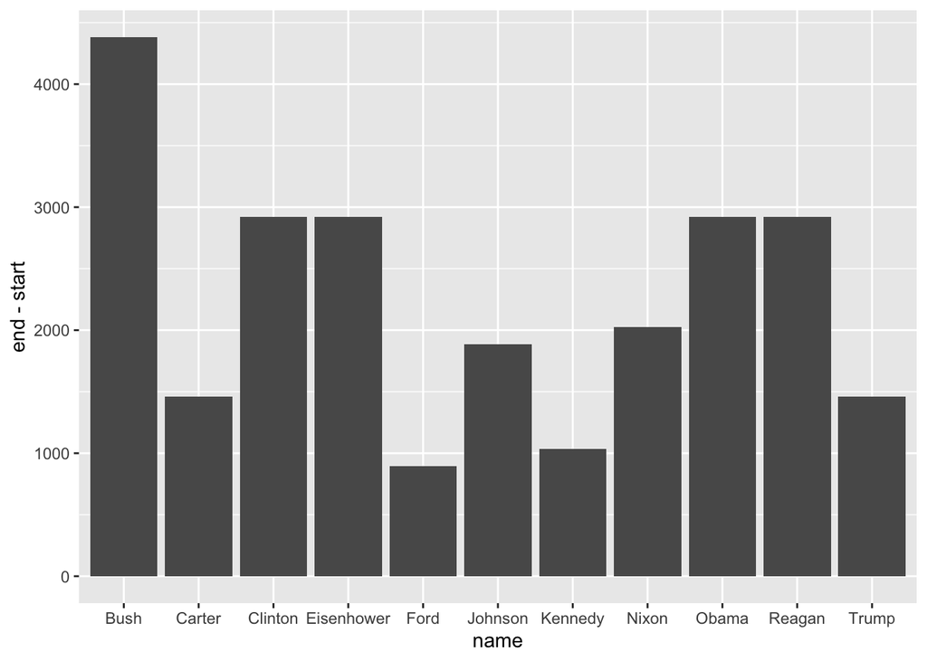

```r
# Step 1: Look at the dataset "presidential" either
# View(presidential)

# Step 2: Plot the number of days in office (end date in office - starting date in office) of each president
ggplot(presidential, aes(x = name, y = end-start)) +
  geom_bar(stat = "identity")
```

### Advanced coding: If statements and for loops

Finally, we will look at two methods to make coding a lot easier and smoother. The first one allows you to work with logical expressions, e.g. if some condition is true or false. The second approach, for loops, are very tricky to build but extremely useful when you want to iterate through content. Don’t worry if these seem very advanced at first. Over time you will get better at constructing both if statements and for loops, or you find yourself using existing loops written by other programmers.

##### 21. If & if-else statements

If and if else statements are a way to control the flow of a program. They allow the programmer to specify certain conditions and then determine what actions should be taken depending on whether or not those conditions are met.

An if statement in R looks like this:

```r
if(condition) {
    # code to be executed if condition is TRUE
}
```

The condition is a logical expression that will either evaluate to TRUE or FALSE. If the condition is TRUE, then the code within the curly braces will run. If the condition is FALSE, the code will be skipped.

Here’s an example:

```r
y <- 5

if (y > 3) {
  print("y is greater than 3")
}
```

```
## [1] "y is greater than 3"
```

*Note:* The **curly braces** ({}) in R are used to define a block of code that belongs together. In the context of an if statement, the curly braces are used to define the code that should be executed if the condition is true.

Next, up, we want to specify our if-statement a bit more.

Therefore, you can also include an “else” clause in an if statement to specify code that should be executed if the condition is FALSE:

```r
if(condition) {
    # code to be executed if condition is TRUE
} else {
    # code to be executed if condition is FALSE
}
```

For example, the following code will print “f is greater than g” if the value of f is greater than the value of g, and “f is less than or equal to g” if the value of f is less than or equal to the value of g:

```r
f <- 5
g <- 3

if(f > g) {
    print("f is greater than g")
} else {
    print("f is less than or equal to g")
}
```

```
## [1] "f is greater than g"
```

In conclusion, if and if else statements are a powerful tool for controlling the flow of a program. They allow you to specify conditions and determine what actions should be taken depending on whether or not those conditions are met.

##### 22. For loops

A “for loop” is a type of loop in R that allows you to iterate over a sequence of elements, such as a vector or a list. It is used to repeat a certain set of instructions a specific number of times.

The basic structure of a for loop in R is as follows:

```r
for (variable in sequence) {
    # code to be executed for each element in the sequence
}
```

The variable is a temporary place holder that will take on the value of the next element in the sequence each time the loop iterates. It is common to call the variable “i”, but by now means a must. You can pick whatever variable name makes logically sense. The sequence can be a vector, list or a range of numbers.

**Example 1**

Here is an example of a for loop that iterates over a vector of numbers:

```r
numbers <- c(1, 2, 3, 4, 5) # Create a vector storing the numbers 1-5 and call it "numbers"

for (i in numbers) { # Read: for every element (called "i") in the object "numbers" (which happens to be a vector)
  print(i) # apply this function
}
```

```
## [1] 1
## [1] 2
## [1] 3
## [1] 4
## [1] 5
```

In this example, the for loop iterates over the vector “numbers”, applying the function print() to each element in the vector. Thereby, the variable “i” first takes on the value of the first element in the vector, that is 1 and applies the function print() to it = it prints the number 1. In the next run through the loop, “i” takes on the value of the second element, that is 2, applies the dunction print() and the output is, that R prints the number 2. The loop is repeated as many times as there are elements in the vector. The code within the loop, which in our case is the print statement, is executed for each value of “i”, resulting in the numbers 1 through 5 being printed to the console.

**Again, note** that the **curly braces** ({}) in R are used to define a block of code that belongs together. In the context of a for loop, the curly braces are used to define the code that should be executed for each iteration of the loop.

**Example 2**

Instead of looping through a vector, you can also use range of numbers to loop over, for example from 1 to 8. Note that R does not use a dash (-) as is commonly done to display ranges. Instead it uses a colon:

```r
1:8 # Write a range of numbers from 1 to 8
```

```
## [1] 1 2 3 4 5 6 7 8
```

Now we can run a loop over a range:

```r
for (i in 1:10) {
  print(i)
}
```

```
## [1] 1
## [1] 2
## [1] 3
## [1] 4
## [1] 5
## [1] 6
## [1] 7
## [1] 8
## [1] 9
## [1] 10
```

In this example, the for loop iterates over the range of numbers from 1 to 10, and each time through the loop, the variable “i” takes on the value of the next number in the range. So the first time through the loop, “i” is equal to 1, the second time through the loop “i” is equal to 2, and so on. The code within the loop, which is just the print statement, is executed for each value of “i”, resulting in the numbers 1 through 10 being printed to the console.

Note, that there is another related expression in R which is called a while-loop. In the current lab, we will not go into depth on while loops but if you would like to receive more information you can contact us or look for practice examples online.

**Example 3**

In the following we want to show you a few more complicated loops, combining loops with other things we have learned in this lab.

Here’s an example of a function that takes a vector as an input and returns a new vector that contains the square of each element in the input vector:

```r
# Creating a new function that can calculate the square of a vector

square_vector <- function(vec) {
    squared_vec <- c()
    for (i in vec) {
        squared_vec <- c(squared_vec, i^2)
    }
    return(squared_vec)
}
```

If this looks complicated to you at first, try to break it down and follow every part of the code. Here are some explanations:

```r
# Creating a new function that can calculate the square of a vector

square_vector <- function(vec) { # create a function to square the elements of a vector and call it "square_vector", the input to the new function is the placeholder variable "vec" indicating that we will apply our new function to an input vector later
    squared_vec <- c() # initialize an empty vector to store the squared values, this will be the output later
    for (i in vec) {   # iterate over the elements of the input vector "vec"
        squared_vec <- c(squared_vec, i^2) # square the current element of the input vector and append it to the new vector
    } # End of for loop
    return(squared_vec) # return the new vector as an output of the function
} # end of function building
```

Now, let’s have a look at how we can make use of our new function:

```r
# test the function
x <- c(1, 2, 3, 4, 5) # create an example vector containing the values 1 to 5
square_vector(x) # call the new function on the example vector "x"
```

```
## [1]  1  4  9 16 25
```

And another application:

```r
bacteria_populations <- c(10, 8, 7, 5.5, 16) # create an example vector that stores different bacteria populations from five samples (numbers in millions)

square_vector(bacteria_populations) # apply our function to see how many bacteria we have in the populations after one generation (in the so-called exponential or log phase bacteria grows exponentially)
```

```
## [1] 100.00  64.00  49.00  30.25 256.00
```

##### 23. Sub-setting

Another handy skill in R is subsetting. Subsetting refers to the process of selecting a subset of data from a larger data set based on certain criteria. In the context of a data frame, subsetting typically involves selecting specific columns or rows of the data frame based on their names or values.

There are two options to select a variable from a data frame, namely the dollar-sign operator or the [[ operator. The $ operator is used to extract a variable by name from a data frame, while the [[ operator is used to extract a variable by name or position from a data frame.

Example:

You want to look at the different values in the variable countries (cntry) in the ess_data dataframe:

```r
# Option A: Select by the number of the column
unique(ess_data[[3]]) # the function unique prints every unique value in the variable instead of printing out the whole variable
```

```
##  [1] "BG" "CH" "CZ" "EE" "FI" "FR" "GR" "HR" "HU" "IS" "IT" "LT" "ME" "MK" "NL"
## [16] "NO" "PT" "SI" "SK"
```

```r
# Option B: Select by the name of the column using the [[ ]]operator
unique(ess_data[["cntry"]])
```

```
##  [1] "BG" "CH" "CZ" "EE" "FI" "FR" "GR" "HR" "HU" "IS" "IT" "LT" "ME" "MK" "NL"
## [16] "NO" "PT" "SI" "SK"
```

```r
# Option c: Using the $ operatior - this is the most commonly used option
unique(ess_data$cntry)
```

```
##  [1] "BG" "CH" "CZ" "EE" "FI" "FR" "GR" "HR" "HU" "IS" "IT" "LT" "ME" "MK" "NL"
## [16] "NO" "PT" "SI" "SK"
```

##### 24.Syntax and Piping

One of the features that makes R so useful is its ability to easily manipulate data using a technique called “piping.” Piping is a way to chain together multiple functions in a way that makes your code more readable and easier to understand.

At its core, piping in R involves using the %>% operator to take the output of one function and pass it as the input to another function. This can be especially useful when working with data frames, as it allows you to easily perform a series of operations on the data without having to create intermediate objects or nest functions.

Here is a brief introduction video on [piping](https://www.youtube.com/watch?v=3PMBr1RhdqM)

For example, suppose you use the data frame we created earlier “ess_data” and you want to 1. filter the respondents by their age, first looking at all participants younger or equal to 40 and then at all those who are older than 40 2. group the selected participants by gender (variable = gndr) 3. summaries their average responses on the happiness item “How happy are you?” (variable = happy)

Instead of computing all of these steps seperately, we can use the pipe operator to send the output of one operation directly into the next one.

```r
# Install and run the package "dplyr" which contains the piping operator %>%
# install.packages("dplyr")
library(dplyr)
# For all participants younger or equal to 40 years
ess_data %>%
  filter(agea <= 40) %>%
  group_by(gndr) %>%
  summarise(mean_happiness = mean(happy))
```

```
## # A tibble: 2 × 2
##    gndr mean_happiness
##   <int>          <dbl>
## 1     1           7.65
## 2     2           7.75
```

```r
# For all participants older than 40
ess_data %>%
  filter(agea > 40) %>%
  group_by(gndr) %>%
  summarise(mean_happiness = mean(happy))
```

```
## # A tibble: 2 × 2
##    gndr mean_happiness
##   <int>          <dbl>
## 1     1           7.29
## 2     2           7.23
```

### That’s it!

If you have any questions you can always reach out to us. And don’t forget, as a coder the internet is your friend. Error messages can almost always be inserted into a search engine of your choice. Most problems have been encountered by other users before you, the tricky part is to understand the solutions and knowing how to look for them.

If you want a more compressed overview on base R you can have a look at [the base R cheat sheet](https://iqss.github.io/dss-workshops/R/Rintro/base-r-cheat-sheet.pdf).

Now, we would like to invite you to play around with the code in this lab, test your own ideas (there is nothing you can break) and we wish you fun getting to know your R environment!